# Analytics Edge: Unit 8 - Radiation Therapy

Sulman Khan

October 26, 2018

## Radiation Therapy

### Cancer

- Cancer is the second leading cause of death in the United States, with an estimated **570,000 deaths** in 2013
- Over **1.6 million new cases** of cancer will be diagnosed in the United States in 2013
- In the world, cancer is also a leading cause of death - **8.2 million deaths** in 2012

### Radiation Therapy

- Cancer can be treated using radiation therapy (RT)
- In RT, beams of high energy photons are fired into the patient that are able to kill cancerous cells
- In the United States, about **half of all cancer patients** undergo some form of radiation therapy

### History of Radiation Therapy

- X-rays were discovered by Wilhelm Röntgen in 1895 (awarded the first Nobel Prize in Physics in 1901)
  - Shortly after, x-rays started being used to treat skin cancers
- Radium discovered by Marie and Pierre Curie in 1898 (Nobel Prize in Chemistry in 1911)
  - Begun to used to treat cancer, as well as other diseases
- First radiation delivery machines (linear accelerators) developed in 1940
- Computed tomography (CT) invented in 1971
- **Invention of intensity-modulated radiation therapy (IMRT) in early 1980s**

### IMRT

- To reach the tumor, radiation passes through healthy issue, and damages both healthy and cancerous tissue
- Damage to healthy tissue can lead to undesirable side effects that reduce post-treatment quality of life
- We want the dose to “fit” the tumor as closely as possible, to reduce the dose to healthy tissues
- In IMRT, the intensity profile of each beam is non-uniform
- By using non-uniform intensity profiles, the three-dimensional shape of the dose can better fit the tumor

### Using Traditional Radiation Therapy

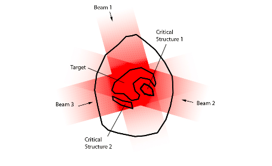

### Using IMRT

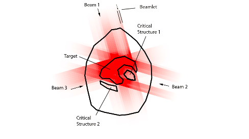

### Designing an IMRT Treatment

- Fundamental problem:
  - How should the beamlet intensities be selected to deliver a therapeutic dose to the tumor *and* to minimize damage to healthy tissue

### The Data

- Treatment planning starts from a CT scan
  - A radiation oncologist contours (draws outlines) around the tumor and various critical structures
  - Each structure is discretized into voxels (volume elements) - typically 4 mm x 4 mm x 4 mm

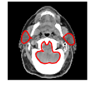

- From CT scan, can compute how much dose each beamlet delivers to every voxel

### Small Example - 9 Voxels, 6 Beamlets

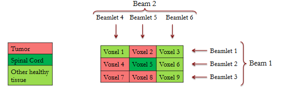

- Minimize total dose to healthy tissue (spinal + other)
- Constraints: tumor voxels at least 7Gy (Gray) , spinal cord voxel at most 5Gy

#### The Model

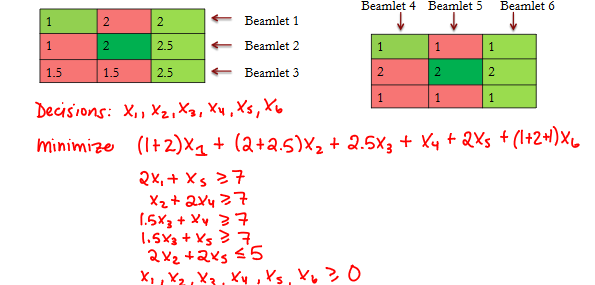

### A Head and Neck Example

- We will test out this approach on a head-and-neck case
  - Total of 132,878 voxels
  - One target volume (9,777 voxels)
  - Five critical structures: spinal cord, brain, brain stem, parotid glands, mandible (jaw)
  - 5 beams; each beam ~60 beamlets (1cm x 1cm) for a total of 328 beamlets

#### Treatment Plan Criteria

- Dose to whole tumor between 70Gy and 77Gy
- Maximum spinal cord at most 45Gy
  - Significant damage to any voxel will result in loss of function
- Maximum brain stem dose at 54Gy
- Maximum mandible dose at most 70Gy
- Mean parotid gland dose at most 26Gy
  - Parotid gland is a parallel structure: significant damage to any voxel does not jeopardize function of entire organ

#### The Optimization Problem

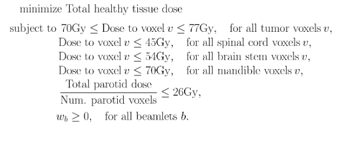

#### Solution

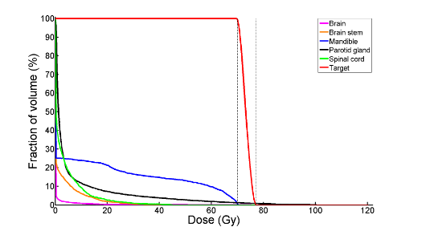

#### Exploring Different Solutions

- Mean mandible dose was 11.3Gy - how can we reduce this?
- one approach: modify objective function
  - Current objective is the sum of the total dose

  $$T_B + T_{BS} + T_{SC} + T_{PG} + T_{M}$$
  - Change objective to

  $$T_B + T_{BS} + T_{SC} + T_{PG} + 10T_{M}$$
  - Set mandible weight from 1 (current solution) to 10

#### New Solution

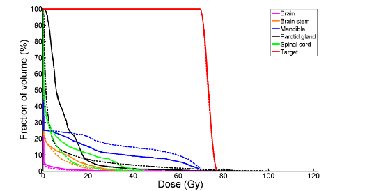

#### Sensitivity

- Another way to explore tradeoffs is to modify constraints
  - For example: by relaxing the mandible maximum dose constraint, we may improve our total healthy tissue dose
  - How much does the objective change for different constraints?

#### Shadow Prices

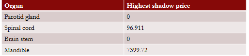

- Parotid gland and brain stem have shadow prices of zero
  - Modifying these constraints is not beneficial
- Mandible has highest shadow price
  - If a slight increase in mandible dose is acceptable, total healthy tissue dose can be significantly reduced

### IMRT Optimization in Practice

- Radiation machines are connected to treatment planning software that implements and solves optimization models (linear and other types)
  - Pinnacle by Philips
  - RayStation by RaySearch Labs
  - Eclipse by Varian

### Extensions

- Selection of beam angles
  - Beam angles can be selected jointly with intensity profiles using **integer optimization**
- Uncertainty
  - Often quality of IMRT treatments is degraded due to uncertain organ motion (e.g., in lung cancer, patient breathing)
  - Can manage uncertainty using a method known as **robust optimization**

### Efficiency

- Manually designing an IMRT treatment is inefficient and impractical
- Linear optimization provides an *efficient* and *systematic way of designing an IMRT treatment*
  - Clinical criteria can be modeled using constraints
  - By changing the model, treatment planner can explore tradeoffs

### Clinical Benefits

- Ultimately, IMRT Benefits the patient
  - In head and neck cancers, saliva glands were rarely spared prior to IMRT; optimized IMRT treatments spare saliva glands
  - In prostate cancer, optimized IMRT treatments reduce toxicities and allow for higher tumor doses to be delivered safely
  - In lung cancer, optimized IMRT reduces risk of radiation-induced pneumonia